# Fluoxetine microbiome analyses

Gabriel Melhado

2026-04-27

# SETUP

## Libraries

```r
# Load packages
pacman::p_load(readr, readxl, here, dplyr, tidyr, tidyverse, forcats, scales, RColorBrewer, grid, janitor, stringr, tibble, phyloseq, vegan, microbiome, microViz, ggside, pairwiseAdonis, DESeq2, ggplot2, lme4, lmerTest, glmmTMB)
```

# Data

## Data wrangling

### Metadata

```r
# Read and prepare metadata
meta <- read_csv(here("data", "experimental_data.csv"))
# Add .fastq to sample column so that it will match the sequence data and make them row names
meta$sample_id <- paste(meta$sample_id, ".fastq", sep = "")
meta <- meta %>%
  remove_rownames() %>%
  column_to_rownames(var = "sample_id")

# Create phyloseq object
mtd_final <- sample_data(meta)
```

### Sequencing information

```r
# Feature table (ASVs count and taxonomy info using Naive Bayes classifier)
biom_NB <- import_biom(
  "data/feature-table-tax.biom",
  treefilename = "data/phylotree_mafft_rooted.nwk"
)

# Feature table (ASVs count and taxonomy info using VSEARCH)
biom_VSEARCH <- import_biom(
  "data/feature-table-tax_vsearch.biom",
  treefilename = "data/phylotree_mafft_rooted.nwk"
)
```

# Generate phyloseq objects. Note that the Naive Bayes and VSEARCH classifications returned similar ASV-level outputs/taxonomic patterns. We therefore proceeded with the Naive Bayes classification for downstream analyses.

# ps_tss will be used for plots and alpha/beta diversity.

# ps_NB includes raw counts and will be used for differential abundance analysis.

### Phyloseq object

```r
# Merge feature table with metadata to create phyloseq object
ps_NB_raw <- merge_phyloseq(mtd_final, biom_NB)
# Fix tax_table so that the column names are correctly names
colnames(tax_table(ps_NB_raw)) <- c("Domain", "Phylum", "Class", "Order", "Family", "Genus", "Species")

# Total sum scaling: converts raw counts into proportions
ps_tss_raw <- transform_sample_counts(ps_NB_raw, function(x){if(sum(x) == 0){x} # avoid producing naN when the sample count is zero
  else {x / sum(x)}})
```

## Data filtering

### Taxonomy-based filtering

```r
# Remove features without a phylum-level annotation and those assigned as chloroplast or mitochondria.

# Filter datasets
ps_tss <- ps_tss_raw %>%
  subset_taxa(!is.na(Phylum) & !Phylum %in% c("", "uncharacterised")) %>%
  subset_taxa(Order != "o__Chloroplast" | is.na(Order)) %>%
  subset_taxa(Family != "f__Mitochondria" | is.na(Family)) %>%
  subset_taxa(Phylum != "p__Chlorophyta")

ps_NB <- ps_NB_raw %>%
  subset_taxa(!is.na(Phylum) & !Phylum %in% c("", "uncharacterised")) %>%
  subset_taxa(Order != "o__Chloroplast" | is.na(Order)) %>%
  subset_taxa(Family != "f__Mitochondria" | is.na(Family)) %>%
  subset_taxa(Phylum != "p__Chlorophyta")
```

#### Prevalence-based filtering

# Features that show up in only a few samples may not represent real biological diversity but rather PCR/sequencing errors (such as PCR chimeras) or reagent contaminants.

```r
# Prevalence filter (remove features present in less than 10% of samples)
prev_cut <- ceiling(0.10 * nsamples(ps_NB))
ps_NB <- filter_taxa(ps_NB, function(x) sum(x > 0) >= prev_cut, prune = TRUE)
```

### Check filtering

```r
# Check the number of taxa that remain after filtering
ntaxa(ps_NB_raw) # Pre-filtering = 15768
```

```
## [1] 15768
```

```r
ntaxa(ps_NB) # Post-filtering = 261
```

```
## [1] 261
```

```r
# Check that no samples have been removed
nsamples(ps_NB_raw) # 129 -> all good
```

```
## [1] 129
```

```r
nsamples(ps_NB) # 129 -> all good
```

```
## [1] 129
```

```r
# Check the number of reads that were left after filtering
sum(taxa_sums(ps_NB)) / sum(taxa_sums(ps_NB_raw)) * 100
```

```
## [1] 79.55518
```

```r
# 79.5% of reads have been retained.
```

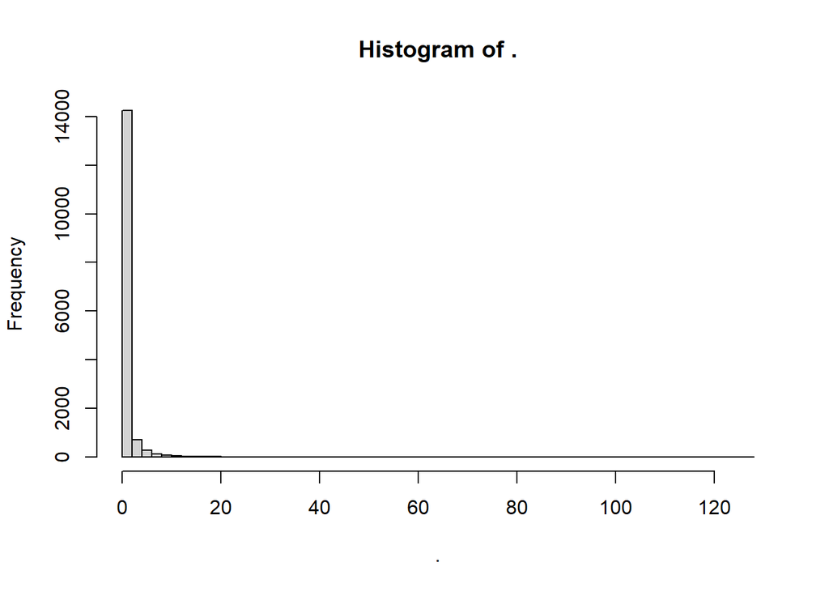

```r
# Plot histograms to ensure that early peaks have been removed
apply(otu_table(ps_NB_raw), 1, function(x) sum(x > 0)) %>%
  hist(breaks = 50)
```

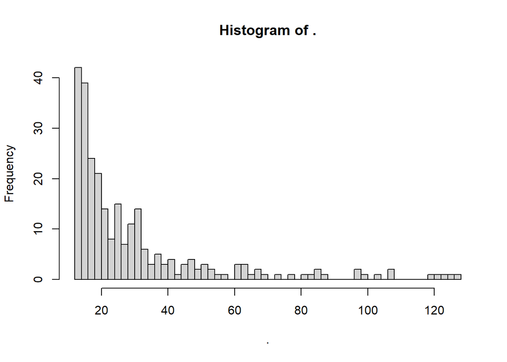

```r
apply(otu_table(ps_NB), 1, function(x) sum(x > 0)) %>%
  hist(breaks = 50)
```

# Alpha diversity

“Alpha-diversity is the diversity in a single ecosystem or sample. The simplest measure is richness, the number of species (or OTUs) observed in the sample. Other metrics consider the abundances (frequencies) of the OTUs, for example to give lower weight to lower-abundance OTUs.” - Robert Edgar

Essentially, alpha diversity measures within-sample diversity across treatments. It is used to evaluate richness and abundance of microbial communities.

Initial plot: Use the phyloseq library to investigate the alpha diversity measure of each sample across the three treatment groups. Note that we will only use a subset of these measures (explained in further detail below).

## 📈 Initial plot

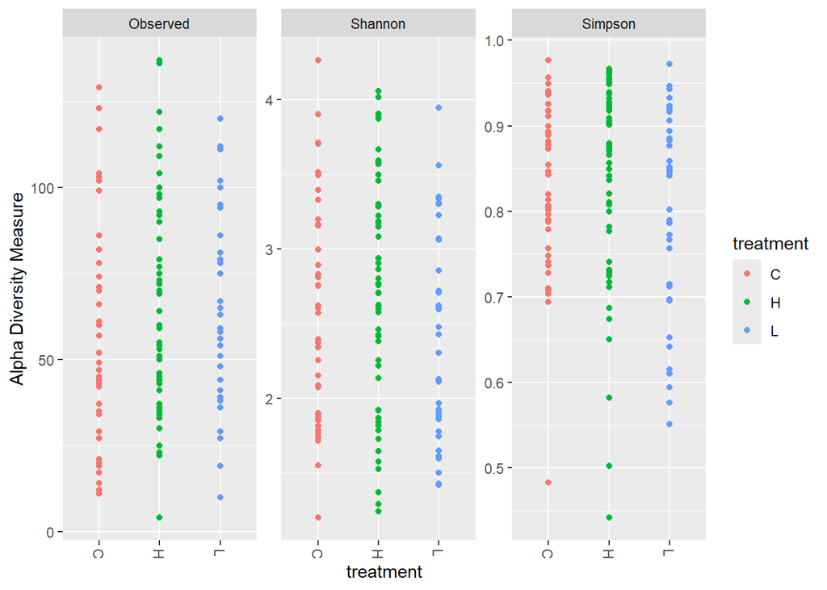

```r
plot_richness(ps_NB, x="treatment", color="treatment",
              measures = c("Observed","Shannon","Simpson"))
```

## 🧮 Calculate alpha diversity

There are many different measures of alpha diversity: - Observed: The actual number of unique ASVs in a sample. Measures taxonomic richness. - ACE: Abundance-based coverage estimator. Based on the abundance of species and estimates the no. of additional species that are likely to be present but have not been observed. - Shannon: Takes into account both species richness and species evenness. It is calculated based on the logarithm of the relative abundances of species in a community. - Simpson’s Diversity Index: Takes into account the number of species present, as well as the relative abundance of each species. 1 = infinite diversity, 0 = no diversity. Measures dominance (i.e., evenness) - Fisher: Takes into account both the number of species (species richness) and the evenness of their distribution. - Chao1: Estimates the true number of species (species richness) in a community or sample, especially when some species are rare and may not be observed in the sample. It takes into account both the number of observed species and the number of rare or singleton species to provide an estimate of total species richness.

```r
# Get alpha values for each sample
alpha <- estimate_richness(ps_NB) %>%
  as.data.frame() %>%
  rownames_to_column(var = "sample") %>%
  mutate(sample = as.character(gsub("X", "", sample)))
# Produces a warning about the lack of singletons (ASVs with a count of 1). This is OK given that the data has been denoised by AGRF, which removes singletons. Note that Chao1 should not be used as it uses singletons in its formula.

# Make sure sample IDs are included in the metadata
IDs <- meta %>%
  rownames_to_column("sample")

# Combine metadata with alpha values
alpha_mtd <- merge(x = IDs, y = alpha, by = "sample")
```

## ❓ Analysis:

Is there evidence that alpha values differ across treatment groups? Note that we only report results from Observed, Shannon, and Simpson measures of diversity.

```r
#Tank-level replication
# add sequencing depth
alpha_mtd$reads <- sample_sums(ps_NB)[alpha_mtd$sample]
alpha_mtd$log_reads <- log(alpha_mtd$reads)


#Observed
m_observed <- glmmTMB(
  Observed ~ treatment + log_reads + (1 | tank),
  data = alpha_mtd,
  family = nbinom2()
)

summary(m_observed)
```

```
##  Family: nbinom2  ( log )
## Formula:          Observed ~ treatment + log_reads + (1 | tank)
## Data: alpha_mtd
##
##      AIC      BIC   logLik deviance df.resid
##   1195.0   1212.2   -591.5   1183.0      123
##
## Random effects:
##
## Conditional model:
##  Groups Name        Variance Std.Dev.
##  tank   (Intercept) 0.1441   0.3796
## Number of obs: 129, groups:  tank, 21
##
## Dispersion parameter for nbinom2 family (): 8.24
##
## Conditional model:
##             Estimate Std. Error z value Pr(>|z|)
## (Intercept)  1.52360    0.31979   4.764 1.89e-06 ***
## treatmentH   0.21992    0.21223   1.036     0.30
## treatmentL   0.12702    0.22954   0.553     0.58
## log_reads    0.25035    0.02945   8.500  < 2e-16 ***
## ---
## Signif. codes:  0 '***' 0.001 '**' 0.01 '*' 0.05 '.' 0.1 ' ' 1
```

```r
#Shannon
m_shannon <- lmer(
  Shannon ~ treatment + log_reads + (1 | tank),
  data = alpha_mtd
)

anova(m_shannon)
```

```
## Type III Analysis of Variance Table with Satterthwaite's method
##            Sum Sq Mean Sq NumDF   DenDF F value  Pr(>F)
## treatment 0.11937 0.05968     2  17.189  0.2012 0.81965
## log_reads 0.91816 0.91816     1 119.660  3.0952 0.08108 .
## ---
## Signif. codes:  0 '***' 0.001 '**' 0.01 '*' 0.05 '.' 0.1 ' ' 1
```

```r
summary(m_shannon)
```

```
## Linear mixed model fit by REML. t-tests use Satterthwaite's method [
## lmerModLmerTest]
## Formula: Shannon ~ treatment + log_reads + (1 | tank)
##    Data: alpha_mtd
##
## REML criterion at convergence: 256.5
##
## Scaled residuals:
##      Min       1Q   Median       3Q      Max
## -2.55810 -0.57725 -0.06199  0.70775  1.92451
##
## Random effects:
##  Groups   Name        Variance Std.Dev.
##  tank     (Intercept) 0.3363   0.5799
##  Residual             0.2966   0.5447
## Number of obs: 129, groups:  tank, 21
##
## Fixed effects:
##               Estimate Std. Error         df t value Pr(>|t|)
## (Intercept)   1.908890   0.413604  86.979526   4.615 1.34e-05 ***
## treatmentH    0.172238   0.321378  17.031984   0.536   0.5989
## treatmentL   -0.009766   0.347409  17.388405  -0.028   0.9779
## log_reads     0.063969   0.036360 119.660321   1.759   0.0811 .
## ---
## Signif. codes:  0 '***' 0.001 '**' 0.01 '*' 0.05 '.' 0.1 ' ' 1
##
## Correlation of Fixed Effects:
##            (Intr) trtmnH trtmnL
## treatmentH -0.407
## treatmentL -0.369  0.497
## log_reads  -0.822 -0.013 -0.020
```

```r
#Simpson
m_simpson <- lmer(
  Simpson ~ treatment + log_reads + (1 | tank),
  data = alpha_mtd
)

anova(m_simpson)
```

```
## Type III Analysis of Variance Table with Satterthwaite's method
##              Sum Sq   Mean Sq NumDF   DenDF F value Pr(>F)
## treatment 0.0095636 0.0047818     2  16.697  0.4649 0.6361
## log_reads 0.0201728 0.0201728     1 123.914  1.9613 0.1639
```

```r
summary(m_simpson)
```

```
## Linear mixed model fit by REML. t-tests use Satterthwaite's method [
## lmerModLmerTest]
## Formula: Simpson ~ treatment + log_reads + (1 | tank)
##    Data: alpha_mtd
##
## REML criterion at convergence: -182.9
##
## Scaled residuals:
##     Min      1Q  Median      3Q     Max
## -3.4633 -0.4177  0.1823  0.6675  1.5739
##
## Random effects:
##  Groups   Name        Variance Std.Dev.
##  tank     (Intercept) 0.002865 0.05352
##  Residual             0.010286 0.10142
## Number of obs: 129, groups:  tank, 21
##
## Fixed effects:
##               Estimate Std. Error         df t value Pr(>|t|)
## (Intercept)   0.913095   0.064980 103.482183  14.052   <2e-16 ***
## treatmentH    0.007161   0.034934  16.367966   0.205    0.840
## treatmentL   -0.027216   0.038086  17.126563  -0.715    0.484
## log_reads    -0.008910   0.006362 123.913531  -1.400    0.164
## ---
## Signif. codes:  0 '***' 0.001 '**' 0.01 '*' 0.05 '.' 0.1 ' ' 1
##
## Correlation of Fixed Effects:
##            (Intr) trtmnH trtmnL
## treatmentH -0.280
## treatmentL -0.232  0.499
## log_reads  -0.918 -0.013 -0.039
```

```r
## Final plots
png("./alpha_temp2.png", width = 600, height = 300, units = "mm", res = 300)

alpha_mtd %>%
  tidyr::pivot_longer(cols = c("Observed", "Shannon", "Simpson"),
                      names_to = "metric",
                      values_to = "value") %>%
  dplyr::mutate(metric = factor(metric, levels = c("Observed", "Shannon", "Simpson"))) %>%
  ggplot(aes(x = treatment, y = value)) +
  geom_boxplot(
    outlier.shape = NA,
    linewidth = 1.5
  ) +
  geom_jitter(
    aes(colour = treatment),
    height = 0,
    width = 0.25,
    alpha = 0.8,
    size = 5
  ) +
  labs(x = "", y = "") +
  facet_wrap(~metric, scales = "free") +
  scale_colour_manual(values = c(
    "C" = "#7FA6B8",
    "L"     = "#F3AD7A",
    "H"    = "#EC6C31"
  )) +
  theme_bw() +
  theme(
    strip.background = element_rect(fill = "grey90", linewidth = 1.5),
    strip.text = element_text(size = 24, face = "bold"),
    axis.text = element_text(size = 22),
    axis.title = element_text(size = 22, face = "bold"),
    panel.grid = element_blank(),
    legend.position = "none",
    panel.border = element_rect(colour = "black", linewidth = 1.5),
    panel.spacing = unit(1.5, "lines")
  )

dev.off()
```

# Beta diversity

Measures community differences between treatments.

## 🧮 Setup

First, we’ll need to transform the counts so that we account for the number of sequences. Values will no longer be counts, but rather the dominance for each taxa relative to the geometric mean of all taxa on the logarithmic scale.

```r
# CLR transformation
ps_clr <- microbiome::transform(ps_NB, "clr")
# The values are now no longer counts, but a value of dominance for each taxa
```

Next, conduct the Principle Component Analysis (PCA), examine the relative importance of each PC, and generate the ordination.

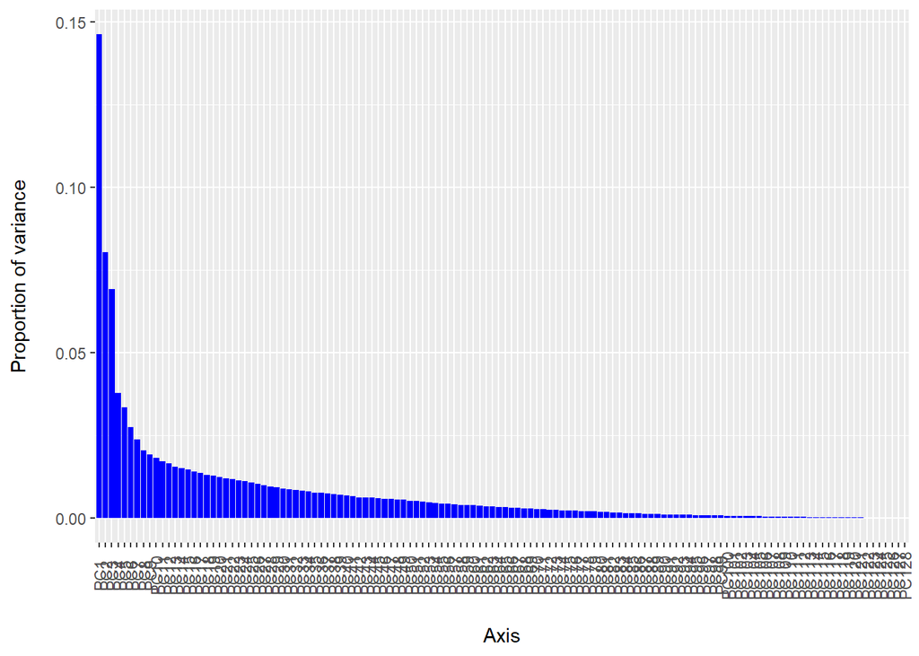

```r
# Generate the principal components
ord_clr <- ordinate(ps_clr, "RDA")

# Plot to examine the proportion of total variation explained by each PC
plot_scree(ord_clr) +
  geom_bar(stat = "identity", fill = "blue") +
  labs(x = "\nAxis", y = "Proportion of variance\n")
```

```r
# Examine the Eigen values () and the the proportion of variance explained
head(ord_clr$CA$eig)
```

```
##       PC1       PC2       PC3       PC4       PC5       PC6
## 127.43456  69.97187  60.36133  32.95894  29.26650  24.00410
```

```r
sapply(ord_clr$CA$eig[1:5], function(x) x / sum(ord_clr$CA$eig))
```

```
##        PC1        PC2        PC3        PC4        PC5
## 0.14639939 0.08038510 0.06934431 0.03786389 0.03362195
```

## 📈 Plot ordination

```r
# Plot the first two components
# We'll scale the plot to reflect the relative amount of information explained by each axis
clr1 <- ord_clr$CA$eig[1] / sum(ord_clr$CA$eig)
clr2 <- ord_clr$CA$eig[2] / sum(ord_clr$CA$eig)
```

```r
png("./PCA_temp_1.png", width = 300, height = 225, units='mm', res = 300)
plot_ordination(ps_NB, ord_clr, type = "samples") +
  coord_fixed(clr1/clr2) +
  stat_ellipse(aes(group = treatment, colour = treatment, fill = treatment),
               geom = "polygon",
               alpha = 0.1,
               linetype = 1,
               linewidth = 0.8,
               level = 0.95) +
    geom_point(aes(fill = treatment),
             size = 2,
             alpha = 0.8,
             shape = 21) +
  scale_fill_manual(values = c("C" = "#7FA6B8",
                               "L" = "#F3AD7A",
                               "H" = "#EC6C31")) +
  scale_colour_manual(values = c("C" = "#7FA6B8",
                                 "L" = "#F3AD7A",
                                 "H" = "#EC6C31")) +
  theme_bw(base_size = 14) +
  geom_xsidedensity(aes(fill = treatment),
                    alpha = 0.5,
                    show.legend = FALSE) +
  geom_ysidedensity(aes(fill = treatment),
                    alpha = 0.5,
                    show.legend = FALSE) +
#  geom_xsideboxplot(aes(fill = treatment, y = treatment),
#                    orientation = "y") +
#  geom_ysideboxplot(aes(fill = treatment, x = treatment),
#                    orientation = "x") +
#  scale_xsidey_discrete(labels = NULL) +
#  scale_ysidex_discrete(labels = NULL) +
  theme_ggside_void()
dev.off()
```

```r
ord_df <- plot_ordination(ps_NB, ord_clr, type = "samples", justDF = TRUE)
png("./PCA_temp_2.png", width = 300, height = 225, units='mm', res = 300)
ggplot(ord_df, aes(x = PC1, y = PC2)) +
  coord_fixed(clr1/clr2) +
    stat_ellipse(aes(group = treatment, colour = treatment),
               alpha = 1,
               linetype = 1,
               linewidth = 1,
               level = 0.95) +
      geom_point(aes(colour = treatment),
             size = 5,
             alpha = 0.8) +
  scale_fill_manual(values = c("C" = "#7FA6B8",
                               "L" = "#F3AD7A",
                               "H" = "#EC6C31")) +
  scale_colour_manual(values = c("C" = "#7FA6B8",
                                 "L" = "#F3AD7A",
                                 "H" = "#EC6C31")) +
  theme_bw(base_size = 14) +
  theme(legend.position = "right",
        legend.title = element_blank(),
        axis.title = element_text(size = 20),
        axis.text = element_text(size = 18),
        axis.line = element_line(color = "black",
                                 linewidth = 0.6),
        panel.border = element_rect(fill = NA,
                                    color = "black",
                                    linewidth = 1.5),
        axis.ticks.length = unit(0.25, "cm"),
        legend.text = element_text(size = 18)) +
  xlab(paste0("PC1 (", round(clr1*100, 1), "%)")) +
  ylab(paste0("PC2 (", round(clr2*100, 1), "%)"))
dev.off()
```